# DR. CARLOS MAURICIO PEREDO

## ACADEMIC RESEARCH

My research aims to make clarity from chaos by focusing on data-driven decision making. I help academic, public, and private stakeholders make informed, evidence-based decisions to inform public and corporate policy. My academic research primarily focuses in two key areas: understanding how changing earth systems drive major evolutionary chance over time; and (2) advancing equity goals and bridging equity gaps in higher education.

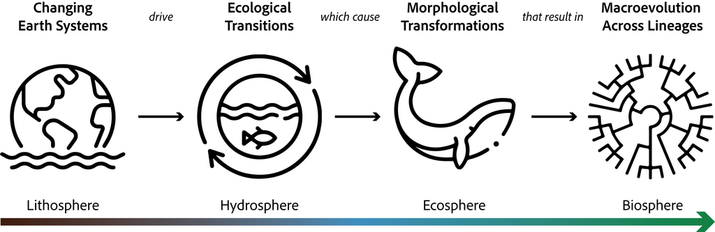

## PUBLISHED RESEARCH PAPERS (20)

20. Ramírez-Díaz, C., M.A. Kolmann, **Peredo, C.M.**, and V.H. Cruz-Escalona. 2024. Cranial musculature of batoids: A standardized nomenclature. **The Anatomical Record**. Early Access. [Read Publication](https://doi.org/10.1002/ar.25527)
19. Medrano, R.A., V.H. Cruz-Escalona, J.A. Payán Alcacio, L.R. de Oliveira, A.O. Vargas, C.J. Hernández-Camacho, and **C.M. Peredo**. 2024. Skull shape and size changes in different populations of Zalophus californianus in Mexico. **Journal of Mammalian Evolution** 105:1, 192–205. [Read Publication](https://doi.org/10.1093/jmammal/gyad104)
18. Nieto-Miranda, J. Jesús, R. Aguilar-Medrano, C.J. Hernández-Camacho, **C.M. Peredo**, V.H. Cruz-Escalona. 2023. Mechanical properties of the California sea lion (*Zalophus californianus*) and northern elephant seal (*Mirounga angustirostris*) lower jaws explain trophic plasticity. **The Anatomical Record** 10, 2598–2609. [Read Publication](https://doi.org/10.1002/ar.25180)
17. **Peredo, C.M.**, N.D. Pyenson, and M.D. Uhen. 2022. Lateral palatal foramina do not indicate baleen in fossil whales. **Scientific Reports** 12, 11448. [Read Publication](https://doi.org/10.1038/s41598-022-15684-8)
16. **Peredo, C.M.**, D.N. Ingle, and C.D. Marshall. 2022. Puncture performance tests reveal distinct feeding modes in pinniped teeth. **Journal of Experimental Biology** 225: 11, jeb244296. [Read Publication](https://doi.org/10.1242/jeb.244296)
15. **Peredo, C.M.**, and N.D. Pyenson. 2021. Morphological variation of the relictual alveolar structures in the mandibles of baleen whales. **PeerJ** 9, e11890. [Read Publication](https://doi.org/10.7717/peerj.11890)
14. Groves*, S.L., **C.M. Peredo**, and N.D. Pyenson. 2021. What are the limits to whale ear bone size? Non-isometric scaling of the cetacean bulla. **PeerJ** 9, e10882. [Read Publication](https://doi.org/10.7717/peerj.10882)
13. Uhen, M.D., and **C.M. Peredo**. 2021. The first possible remingtonocetid stem whale from North America. **Acta Palaeontologica Polonica** 66:1, 77–83. [Read Publication](https://doi.org/10.4202/app.00799.2020)
12. Tate-Jones, M.K., **C.M. Peredo**, C.D. Marshall, and S.S.B. Hopkins. 2020. The dawn of Desmatophocidae: a new species of basal desmatophocid seal (Mammalia, Carnivora) from the Miocene of Oregon, USA. **Journal of Vertebrate Paleontology** 40:4, 1–12. [Read Publication](https://doi.org/10.1080/02724634.2020.1789867)
11. Leslie, M.S., **C.M. Peredo**, and N.D. Pyenson. 2019. *Norrisanima miocaena*, a new generic name and rediscription of a stem balaenopteroid mysticete (Mammalia, Cetacea) from the Miocene of California. **PeerJ** 7, e7629. [Read Publication](https://doi.org/10.7717/peerj.7629)
10. Shipps*, B.K., **C.M. Peredo**, and N.D. Pyenson. 2019.* Borealodon osedax*, a new stem mysticete (Mammalia, Cetacea) from the Oligocene of Washington State and its implications for fossil whale-fall communities. **Royal Society Open Science** 6, 182168. [Read Publication](https://doi.org/10.1098/rsos.182168)
9. **Peredo, C.M.**, N.D. Pyenson, C.D. Marshall, and M.D. Uhen. 2018. Tooth loss precedes the origin of baleen in whales. **Current Biology** 28, 3992–4000. [Read Publication](https://doi.org/10.1016/j.cub.2018.10.047)
8. **Peredo, C.M.**, J.S. Peredo, and N.D. Pyenson. 2018. Convergence on dental simplification in the evolution of whales. **Paleobiology** 44:3, 434–443. [Read Publication](https://doi.org/10.1017/pab.2018.9)
7. **Peredo, C.M.**, and N.D. Pyenson. 2018. *Salishicetus meadi*, a new aetiocetid from the late Oligocene of Washington State and implications for feeding transitions in early mysticete evolution. **Royal Society Open Science** 5, 172336. [Read Publication](https://doi.org/10.1098/rsos.172336)
6. **Peredo, C.M.**, M.D. Uhen, and M.D. Nelson. 2018. A new kentriodontid (*Cetacea: Odontoceti*) from the early Miocene Astoria Formation and a revision of the stem delphinidan family Kentriodontidae. **Journal of Vertebrate Paleontology** 38:2, 1–18. [Read Publication](https://doi.org/10.1080/02724634.2017.1411357)
5. Dewaele, L., **C.M. Peredo**, P. Meyvisch, and S. Louwye. 2018. Diversity of late Neogene Monachinae (Carnivora, Phocidae) from the North Atlantic, with the description of two new species. **Royal Society Open Science** 5, 172437. [Read Publication](https://doi.org/10.1098/rsos.172437)
4. **Peredo, C.M.**, N.D. Pyenson, M.D. Uhen, and C.D. Marshall. 2017. Alveoli, teeth, and tooth loss: Understanding the homology of internal mandibular structures in mysticete cetaceans. **PLOS ONE** 12:5, 1–26. [Read Publication](https://doi.org/10.1371/journal.pone.0178243)
3. **Peredo, C.M.**, N.D. Pyenson, and A.T. Boersma. 2017. Decoupling tooth loss from the evolution of baleen in whales. **Frontiers in Marine Science** 4:67, 1–11. [Read Publication](https://doi.org/10.3389/fmars.2017.00067)
2. **Peredo, C.M.**, and M.D. Uhen. 2016. A new basal chaeomysticete (*Mammalia: Cetacea*) from the Late Oligocene Pysht Formation of Washington, USA. **Papers in Palaeontology** 2:4, 533–554. [Read Publication](https://doi.org/10.1002/spp2.1051)
1. **Peredo, C.M.**, and M.D. Uhen. 2016. Exploration of marine mammal paleogeography in the Northern Hemisphere over the Cenozoic using beta diversity. **Palaeogeography, Palaeoclimatology, Palaeoecology** 449, 227–235. [Read Publication](https://doi.org/10.1016/j.palaeo.2016.02.034)